# Exploratory Data Analysis

Author

Corwin Dark

## EDA Overview

At the broadest level, there is a temporal component to the research question that will shape how we conduct the analysis. Namely, the outcome variable is retail trading activity in stocks, as measured by daily holding data on the top 10 stocks sourced from NASDAQ’s API. As such, we are interested in data from the other datasets (reddit text information, investor sentiment survey, stocktwits ranking) as of one day before. I will merge the datasets in R, and then use R (ggplot) to create visuals and carry out EDA.

## Exploring the Data

```r
library(tidyverse)
library(Quandl)
library(lubridate)
library(RedditExtractoR)
library(reticulate)
library(xlsx)
```

Let’s join the data together into one dataset, with properly lagged predictor variables.

```r
redditIn <- read.xlsx("../data/01-modified-data/sampleRedditText.xlsx", sheetName = "Sheet1")
sentimentIn <- read.csv("../data/00-raw-data/sentiment_aaii.csv")
rtatIn <- read.csv("../data/01-modified-data/cleanRTAT.csv")


# Ensure dates can be joined
colnames(sentimentIn)[1] <- "date"

sentimentIn <- sentimentIn |>
    mutate(date = mdy(date)) |>
    mutate(week = week(date)) |>
    mutate(lagweek = week + 1) |>
    mutate(weekyear = paste(year(date), lagweek )) |>
    mutate(Bullish = as.numeric(str_replace(Bullish, "%", ""))/100 ) |>
    mutate(Neutral = as.numeric(str_replace(Neutral, "%", ""))/100 ) |>
    mutate(Spread = as.numeric(str_replace(Spread, "%", ""))/100 ) |>
    mutate(Bearish = as.numeric(str_replace(Bearish, "%", ""))/100 )


rtatIn <- rtatIn %>%
    mutate(date = ymd(date)) %>%
    mutate(week = week(date)) %>%
    mutate(weekyear = paste(year(date), week))

#head(rtatIn)


joinedSentiment <- left_join(rtatIn, sentimentIn, by = "weekyear")

#head(joinedSentiment)
```

### Numeric Summaries

```r
print("Activity Summary:")
```

```
[1] "Activity Summary:"
```

```r
summary(joinedSentiment$activity)
```

```
   Min. 1st Qu.  Median    Mean 3rd Qu.    Max.
0.00760 0.01720 0.02460 0.03103 0.03590 0.26150
```

```r
print("Sentiment Summary:")
```

```
[1] "Sentiment Summary:"
```

```r
summary(joinedSentiment$sentiment)
```

```
    Min.  1st Qu.   Median     Mean  3rd Qu.     Max.
-23.0000  -1.0000   1.0000   0.9117   3.0000  19.0000
```

```r
print("Change in Activity Summary:")
```

```
[1] "Change in Activity Summary:"
```

```r
summary(joinedSentiment$deltaActivity)
```

```
     Min.   1st Qu.    Median      Mean   3rd Qu.      Max.
-0.194000 -0.003700  0.002100  0.003997  0.011600  0.232000
```

```r
print("Change in Sentiment Summary:")
```

```
[1] "Change in Sentiment Summary:"
```

```r
summary(joinedSentiment$deltaSentiment)
```

```
   Min. 1st Qu.  Median    Mean 3rd Qu.    Max.
-24.000  -3.000   0.000  -1.259   1.000  20.000
```

```r
print("Positive Sentiment Proportion Summary:")
```

```
[1] "Positive Sentiment Proportion Summary:"
```

```r
summary(joinedSentiment$Bullish)
```

```
   Min. 1st Qu.  Median    Mean 3rd Qu.    Max.    NA's
 0.1584  0.2483  0.3188  0.3262  0.3956  0.5691     290
```

```r
print("Negative Sentiment Proportion Summary:")
```

```
[1] "Negative Sentiment Proportion Summary:"
```

```r
summary(joinedSentiment$Bearish)
```

```
   Min. 1st Qu.  Median    Mean 3rd Qu.    Max.    NA's
 0.1976  0.2751  0.3805  0.3732  0.4490  0.6087     290
```

```r
print("Neutral Sentiment Proportion Summary:")
```

```
[1] "Neutral Sentiment Proportion Summary:"
```

```r
summary(joinedSentiment$Neutral)
```

```
   Min. 1st Qu.  Median    Mean 3rd Qu.    Max.    NA's
 0.1450  0.2715  0.3043  0.3005  0.3345  0.4091     290
```

```r
print("Spread in Sentiment Summary:")
```

```
[1] "Spread in Sentiment Summary:"
```

```r
summary(joinedSentiment$Spread)
```

```
    Min.  1st Qu.   Median     Mean  3rd Qu.     Max.     NA's
-0.43100 -0.19200 -0.07500 -0.04695  0.11700  0.36500      290
```

### Barplots for discrete variables:

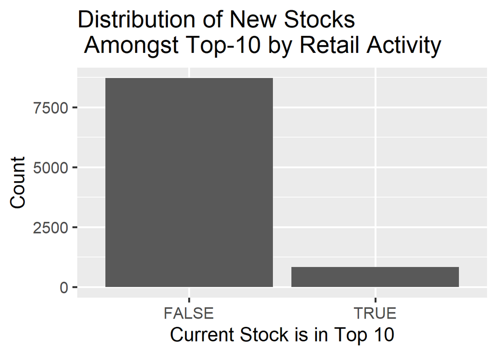

```r
ggplot(joinedSentiment, aes(x = newEntry)) + geom_bar() + labs(x= "Current Stock is in Top 10", y = "Count", title = "Distribution of New Stocks\n Amongst Top-10 by Retail Activity") + theme_grey(base_size = 20)
```

```r
print("Most Popular Stocks by Days in Top 10:")
```

```
[1] "Most Popular Stocks by Days in Top 10:"
```

```r
sort(table(joinedSentiment$ticker), decreasing = TRUE)[1:10]
```

```
AAPL TSLA  SPY  AMD  QQQ TQQQ NVDA AMZN SQQQ MSFT
 956  956  926  876  760  694  665  531  408  389
```

In addition to the porportion of new stocks in the top 10, the table shows up the top 10 stocks by number of days spent in the top-10 ranking of retail investor actvity. We can see that the distribution has a heavy right tail, as even amongst the top 10 stocks there is a large divergence, with the top stock (AAPL) having more than two times as many days in the top 10 as the 10th place stock (MSFT).

### Outcome Variable Exploration

First, lets explore the outcome variable table, of the top 10 retail-investor held stocks each day. Each stock has an ‘activity’ number which measures the percent of traded shares held by retail investors. Let’s see how those scores are distributed:

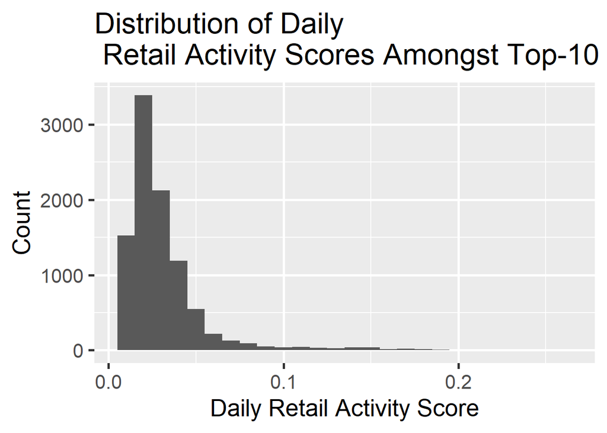

```r
ggplot(joinedSentiment, aes(x = activity)) + geom_bar(stat = 'bin', binwidth = 0.01) + labs(x= "Daily Retail Activity Score", y = "Count", title = "Distribution of Daily \n Retail Activity Scores Amongst Top-10 Stocks") + theme_grey(base_size = 20)
```

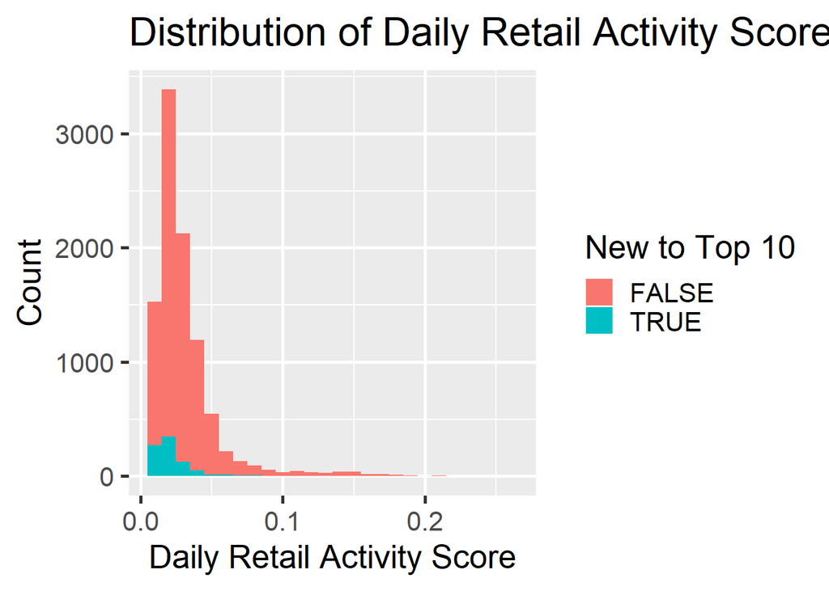

```r
ggplot(joinedSentiment, aes(x = activity, fill = newEntry)) + geom_bar(stat = 'bin', binwidth = 0.01) + labs(x= "Daily Retail Activity Score", y = "Count", title = "Distribution of Daily Retail Activity Scores Amongst Top-10 Stocks", fill = "New to Top 10") + theme_grey(base_size = 20)
```

From this chart, we can see that most of the high-activity scores are from stocks which previously entered the top 10. This makes sense, as we would expects stock to increase in activity over multiple days, before reaching the top of the list. Similar to songs on top music charts.

My next question is how the outcome variable has changed over time. Let’s look at attention scores over time:

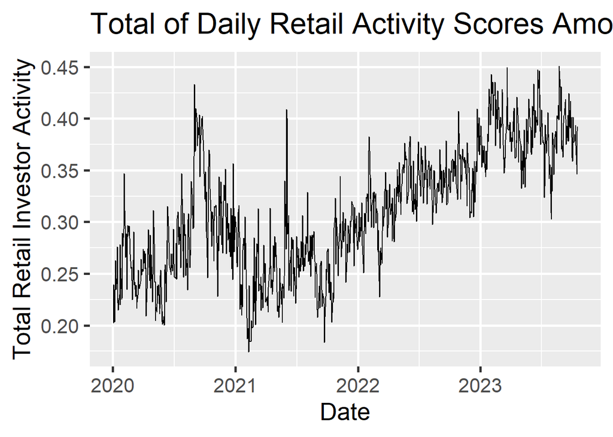

```r
joinedSentimentAvgs <- joinedSentiment %>%
    group_by(date.x) %>%
    summarize(dailyactivitytotal = sum(activity), dailyactivityavg = mean(activity),
    dailynewtickers = sum(as.numeric(newEntry)))

ggplot(joinedSentimentAvgs, aes(x = date.x, y = dailyactivitytotal)) + geom_line() + labs(x= "Date", y = "Total Retail Investor Activity", title = "Total of Daily Retail Activity Scores Amongst Top-10 Stocks", fill = "New to Top 10") + theme_grey(base_size = 20)
```

This chart is interesting because it shows that our outcome variable has a clear upward trend over time. Retail investors appear to be a greater proportion of the total activity in the stock market today than they were in 2020.

One last visual I wanted to create to evaluate the outcome variables was the number of new top-10 stocks that entered the list each week

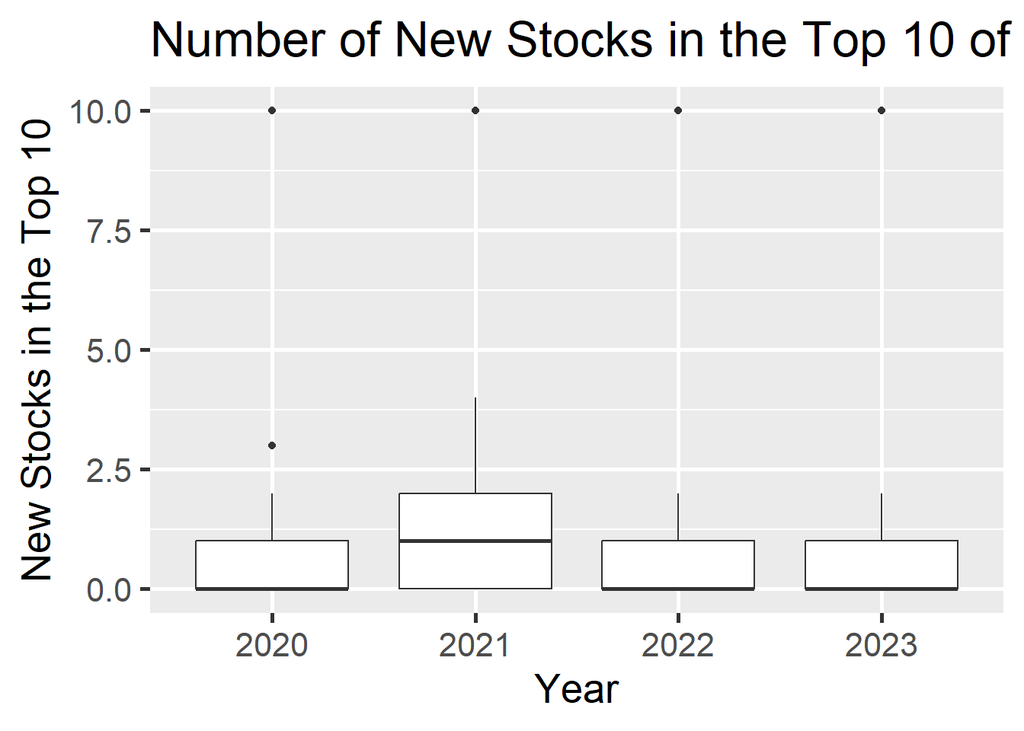

```r
library(ggbeeswarm)

ggplot(joinedSentimentAvgs, aes(x = as.character(year(date.x)), y = dailynewtickers)) + geom_boxplot() + labs(x= "Year", y = "New Stocks in the Top 10", title = "Number of New Stocks in the Top 10 of Retail Activity by Year", fill = "New to Top 10") + theme_grey(base_size = 20)
```

Here we can see there is not a huge difference in the distributions of new stocks between the years, except for 2021, when there was a lot more days with at least 1 new stock in the top 10. But far and away, at least 50% of days have no new stocks in the top 10 of retail trader activity.

### Bivariate Analysis

Now, lets look at some of the predictor variables in relation to the outcome variables.

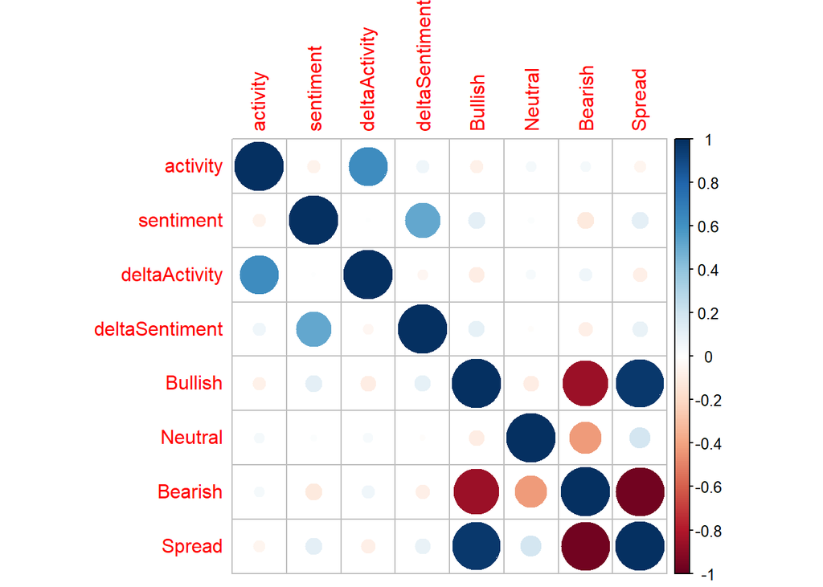

```r
library("corrplot")

noNAsentiment <- na.omit(joinedSentiment[,c(4,5,6,7,12,13,14,17)])

save <- cor(noNAsentiment)
corrplot(save)
```

```r
save
```

```
                  activity    sentiment deltaActivity deltaSentiment
activity        1.00000000 -0.068425337   0.620189979     0.06955678
sentiment      -0.06842534  1.000000000   0.009215771     0.51408474
deltaActivity   0.62018998  0.009215771   1.000000000    -0.04522242
deltaSentiment  0.06955678  0.514084741  -0.045222415     1.00000000
Bullish        -0.07234842  0.111433821  -0.095796815     0.10398764
Neutral         0.04440169  0.019445339   0.038646679    -0.01661078
Bearish         0.04285201 -0.111207408   0.067113719    -0.08588212
Spread         -0.05902646  0.115454510  -0.083795941     0.09801129
                   Bullish     Neutral     Bearish      Spread
activity       -0.07234842  0.04440169  0.04285201 -0.05902646
sentiment       0.11143382  0.01944534 -0.11120741  0.11545451
deltaActivity  -0.09579681  0.03864668  0.06711372 -0.08379594
deltaSentiment  0.10398764 -0.01661078 -0.08588212  0.09801129
Bullish         1.00000000 -0.09615506 -0.85871354  0.96041621
Neutral        -0.09615506  1.00000000 -0.42751147  0.18492522
Bearish        -0.85871354 -0.42751147  1.00000000 -0.96747469
Spread          0.96041621  0.18492522 -0.96747469  1.00000000
```

### Outliers and Segmentation

We already saw in the overtime chart that perhaps 2021 was a different type of year than the other 3, as it had a high percentage of days with new stocks in the top 10.

Lets look at the key outcome variables and see if any values violate Tukey’s rule

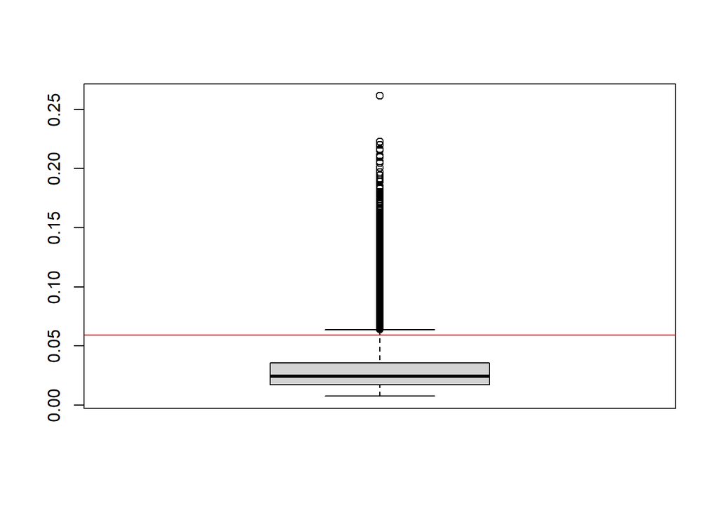

```r
boxplot(joinedSentiment$activity)

cutoff <- mean(joinedSentiment$activity) + (1.5 * IQR(joinedSentiment$activity))

abline(h = cutoff, col = "Red")
```

With the red line above denoting the 1.5*IQR + mean threshold, we can see that many values lie above this line, but they do not appear to be separated from the main distribution. Rather, it looks like the main distribution has a fat right tail. Perhaps it would be well approximated by a Student’s distribution.

### Text Data

Let’s use the TM package to make a cloud of the most popular words in the Reddit posts:

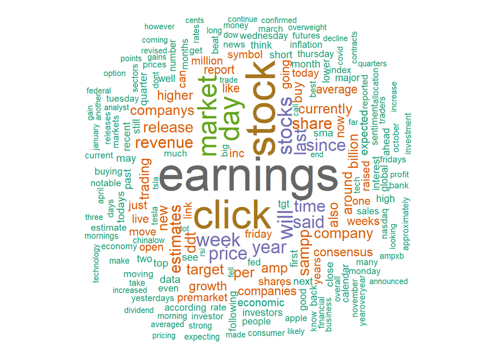

```r
#install.packages("tm")
library(tm)
library(wordcloud)
#Create a vector containing only the text
text <- read.xlsx("../data/01-modified-data/sampleRedditText.xlsx", sheetName = "Sheet1")
text <- text$text

# Create a corpus
docs <- Corpus(VectorSource(text))
docs <- docs %>%
  tm_map(removeNumbers) %>%
  tm_map(removePunctuation) %>%
  tm_map(stripWhitespace)
docs <- tm_map(docs, content_transformer(tolower))
docs <- tm_map(docs, removeWords, stopwords("english"))


dtm <- TermDocumentMatrix(docs)
matrix <- as.matrix(dtm)
words <- sort(rowSums(matrix),decreasing=TRUE)
df <- data.frame(word = names(words),freq=words)

set.seed(1234) # for reproducibility
wordcloud(words = df$word, freq = df$freq, min.freq = 1,           max.words=200, random.order=FALSE, rot.per=0.35,            colors=brewer.pal(8, "Dark2"))
```

The wordcloud is interesting: it contains far more formal language than I would have predicted. Stock trading forums online usually discuss a variety of issues with a varying degree of informalism. I believe the narrow and professional vocabulary in the posts may be due to the particular forum I chose, as the r/stocks subreddit is hyperfocused on discussions of particular stocks. I would hypothesize that the vocabulary and most used words would differ greatly between internet forums, even amongst those that are focused only on investing.

A few notable points from the words displayed: earnings are by far the most common point of discussion, and seem to play an outsize role in why individual investors on the forum are interested in a particular stock. This could indicate than comparing retail investor conversations with earnings events could be a fruitful point of investigation in the future.